# survival collection data (Drosophila)

## Hypothesis Testing

##### Different hypotheses:

Are Pseudomonas entomophila really killing flies?

If P.ent. are pathogenic,

- Are Drosophila males and females different in their susceptibility?
- Are daxx<sup>NP4778</sup> mutants more susceptible than Dahomey wild-types?
- Does raising the larvae in crotonic acid affect the adult immuno-competence?
- Do any of the previous variables interact, i.e. susceptibility only changes in certain combinations of the variables?

```r
# Fit a survival model using the surv_fit function
library(survival)
library(survminer)

# Fit a survival curve
pathogenicity <- survfit(Surv(time_to_event, event_type) ~ treatment_2, data = data_long) # do Pseudomonas kill flies?

# Print the result to check
print(pathogenicity)
```

```
## Call: survfit(formula = Surv(time_to_event, event_type) ~ treatment_2,
##     data = data_long)
##
##                       n events median 0.95LCL 0.95UCL
## treatment_2=P.ent.  487     91     NA      NA      NA
## treatment_2=vehicle 492     62     NA      NA      NA
```

```r
# Calculate the p-value for the survival model using the surv_pvalue function
surv_pvalue(pathogenicity, method = "S1", test.for.trend = FALSE, combine = FALSE)[1:3]
```

```
##      variable   pval    method
## 1 treatment_2 0.0105 Peto-Peto
```

```r
# Fit a survival model using the surv_fit function
sexspec <- surv_fit(Surv(time_to_event, event_type) ~ sex, data = data_long) # does sex affect survival?

# Calculate the p-value for the survival model using the surv_pvalue function
surv_pvalue(sexspec, method = "1", test.for.trend = FALSE, combine = FALSE)[1:3]
```

```
##   variable         pval   method
## 1      sex 4.978296e-15 Log-rank
```

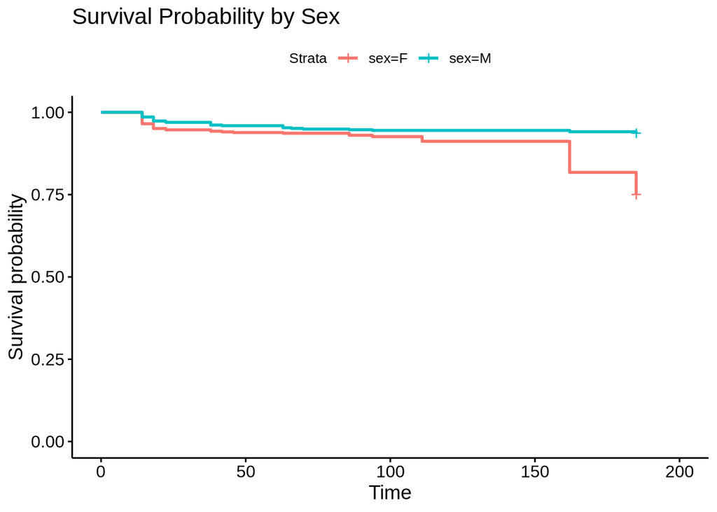

```r
# Plot the survival curves using the ggsurvplot function
ggsurvplot(sexspec) + ggtitle("Survival Probability by Sex")
```

##### Figure 1. This Kaplan-Meier survival curve illustrates the survival probability of flies over time, categorized by sex (male and female), with the x-axis representing time in hours and the y-axis representing survival probability, ranging from 0 to 1. The dataset consists of survival times for male and female flies, comparing the survival of females (red line) and males (blue line) to assess whether sex impacts overall survival. Each step down in the survival curve represents a death event among the flies. The legend indicates the sex groups, with sex=F for females and sex=M for males. Key observations include male flies (blue) generally maintaining a higher survival probability compared to female flies (red) throughout the observation period, with a more pronounced decline in female survival around the 150-hour mark.

```r
# Fit a survival model for infected flies using the surv_fit function
sexspec_inf <- surv_fit(Surv(time_to_event, event_type) ~ sex, data = dplyr::filter(data_long, treatment_2 == 'P.ent.'))

# Calculate the p-value for the survival model using the surv_pvalue function
p_value_inf <- surv_pvalue(sexspec_inf, method = "1", test.for.trend = FALSE, combine = FALSE)[1:3]
print(p_value_inf)
```

```
##   variable         pval   method
## 1      sex 2.000992e-05 Log-rank
```

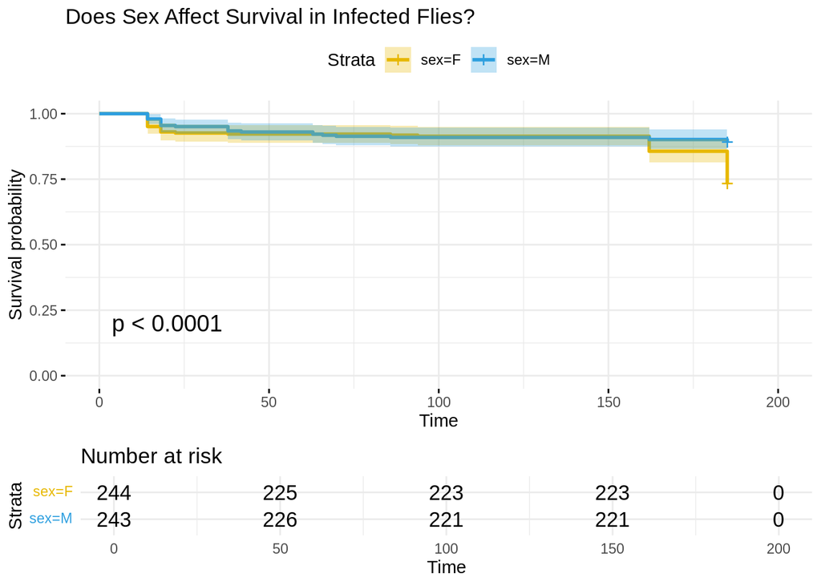

```r
# Plot the survival curves using the ggsurvplot function with specified colors
plot_inf <- ggsurvplot(
  sexspec_inf,
  pval = TRUE,
  conf.int = TRUE,
  risk.table = TRUE,
  ggtheme = theme_minimal(),
  palette = c("#E7B800", "#2E9FDF")  # specify colors here
)

# Add a title to the plot
plot_inf$plot <- plot_inf$plot + ggtitle("Does Sex Affect Survival in Infected Flies?")

# Print the plot
print(plot_inf)
```